# EDA IBM HR Analytics Project

## Employee attrition analysis using pandas,numpay,matplot and seaborn

# Introduction

# Objective

Analyze employee attrition patterns. Identify factors affecting employee satisfaction. Compare salary across departments. Understand overtime impact on attrition. Generate business insights for HR decision-making.

```python
import numpy as np
import pandas as pd
import matplotlib.pyplot as plt
import seaborn as sns
```

```python
df=pd.read_csv(r"C:\Users\sachi\Downloads\WA_Fn-UseC_-HR-Employee-Attrition.csv")
df.head()
```

|  | Age | Attrition | BusinessTravel | DailyRate | Department | DistanceFromHome | Education | EducationField | EmployeeCount | EmployeeNumber | ... | RelationshipSatisfaction | StandardHours | StockOptionLevel | TotalWorkingYears | TrainingTimesLastYear | WorkLifeBalance | YearsAtCompany | YearsInCurrentRole | YearsSinceLastPromotion | YearsWithCurrManager |
| --- | --- | --- | --- | --- | --- | --- | --- | --- | --- | --- | --- | --- | --- | --- | --- | --- | --- | --- | --- | --- | --- |
| 0 | 41 | Yes | Travel_Rarely | 1102 | Sales | 1 | 2 | Life Sciences | 1 | 1 | ... | 1 | 80 | 0 | 8 | 0 | 1 | 6 | 4 | 0 | 5 |
| 1 | 49 | No | Travel_Frequently | 279 | Research & Development | 8 | 1 | Life Sciences | 1 | 2 | ... | 4 | 80 | 1 | 10 | 3 | 3 | 10 | 7 | 1 | 7 |
| 2 | 37 | Yes | Travel_Rarely | 1373 | Research & Development | 2 | 2 | Other | 1 | 4 | ... | 2 | 80 | 0 | 7 | 3 | 3 | 0 | 0 | 0 | 0 |
| 3 | 33 | No | Travel_Frequently | 1392 | Research & Development | 3 | 4 | Life Sciences | 1 | 5 | ... | 3 | 80 | 0 | 8 | 3 | 3 | 8 | 7 | 3 | 0 |
| 4 | 27 | No | Travel_Rarely | 591 | Research & Development | 2 | 1 | Medical | 1 | 7 | ... | 4 | 80 | 1 | 6 | 3 | 3 | 2 | 2 | 2 | 2 |

5 rows × 35 columns

```python
df
```

|  | Age | Attrition | BusinessTravel | DailyRate | Department | DistanceFromHome | Education | EducationField | EmployeeCount | EmployeeNumber | ... | RelationshipSatisfaction | StandardHours | StockOptionLevel | TotalWorkingYears | TrainingTimesLastYear | WorkLifeBalance | YearsAtCompany | YearsInCurrentRole | YearsSinceLastPromotion | YearsWithCurrManager |
| --- | --- | --- | --- | --- | --- | --- | --- | --- | --- | --- | --- | --- | --- | --- | --- | --- | --- | --- | --- | --- | --- |
| 0 | 41 | Yes | Travel_Rarely | 1102 | Sales | 1 | 2 | Life Sciences | 1 | 1 | ... | 1 | 80 | 0 | 8 | 0 | 1 | 6 | 4 | 0 | 5 |
| 1 | 49 | No | Travel_Frequently | 279 | Research & Development | 8 | 1 | Life Sciences | 1 | 2 | ... | 4 | 80 | 1 | 10 | 3 | 3 | 10 | 7 | 1 | 7 |
| 2 | 37 | Yes | Travel_Rarely | 1373 | Research & Development | 2 | 2 | Other | 1 | 4 | ... | 2 | 80 | 0 | 7 | 3 | 3 | 0 | 0 | 0 | 0 |
| 3 | 33 | No | Travel_Frequently | 1392 | Research & Development | 3 | 4 | Life Sciences | 1 | 5 | ... | 3 | 80 | 0 | 8 | 3 | 3 | 8 | 7 | 3 | 0 |
| 4 | 27 | No | Travel_Rarely | 591 | Research & Development | 2 | 1 | Medical | 1 | 7 | ... | 4 | 80 | 1 | 6 | 3 | 3 | 2 | 2 | 2 | 2 |
| ... | ... | ... | ... | ... | ... | ... | ... | ... | ... | ... | ... | ... | ... | ... | ... | ... | ... | ... | ... | ... | ... |
| 1465 | 36 | No | Travel_Frequently | 884 | Research & Development | 23 | 2 | Medical | 1 | 2061 | ... | 3 | 80 | 1 | 17 | 3 | 3 | 5 | 2 | 0 | 3 |
| 1466 | 39 | No | Travel_Rarely | 613 | Research & Development | 6 | 1 | Medical | 1 | 2062 | ... | 1 | 80 | 1 | 9 | 5 | 3 | 7 | 7 | 1 | 7 |
| 1467 | 27 | No | Travel_Rarely | 155 | Research & Development | 4 | 3 | Life Sciences | 1 | 2064 | ... | 2 | 80 | 1 | 6 | 0 | 3 | 6 | 2 | 0 | 3 |
| 1468 | 49 | No | Travel_Frequently | 1023 | Sales | 2 | 3 | Medical | 1 | 2065 | ... | 4 | 80 | 0 | 17 | 3 | 2 | 9 | 6 | 0 | 8 |
| 1469 | 34 | No | Travel_Rarely | 628 | Research & Development | 8 | 3 | Medical | 1 | 2068 | ... | 1 | 80 | 0 | 6 | 3 | 4 | 4 | 3 | 1 | 2 |

1470 rows × 35 columns

```python
df.info()
```

```
<class 'pandas.core.frame.DataFrame'>
RangeIndex: 1470 entries, 0 to 1469
Data columns (total 35 columns):
 #   Column                    Non-Null Count  Dtype
---  ------                    --------------  -----
 0   Age                       1470 non-null   int64
 1   Attrition                 1470 non-null   object
 2   BusinessTravel            1470 non-null   object
 3   DailyRate                 1470 non-null   int64
 4   Department                1470 non-null   object
 5   DistanceFromHome          1470 non-null   int64
 6   Education                 1470 non-null   int64
 7   EducationField            1470 non-null   object
 8   EmployeeCount             1470 non-null   int64
 9   EmployeeNumber            1470 non-null   int64
```

[output cut: 27 more lines]

```python
df.shape
```

```
(1470, 35)
```

```python
df.describe()
```

|  | Age | DailyRate | DistanceFromHome | Education | EmployeeCount | EmployeeNumber | EnvironmentSatisfaction | HourlyRate | JobInvolvement | JobLevel | ... | RelationshipSatisfaction | StandardHours | StockOptionLevel | TotalWorkingYears | TrainingTimesLastYear | WorkLifeBalance | YearsAtCompany | YearsInCurrentRole | YearsSinceLastPromotion | YearsWithCurrManager |
| --- | --- | --- | --- | --- | --- | --- | --- | --- | --- | --- | --- | --- | --- | --- | --- | --- | --- | --- | --- | --- | --- |
| count | 1470.000000 | 1470.000000 | 1470.000000 | 1470.000000 | 1470.0 | 1470.000000 | 1470.000000 | 1470.000000 | 1470.000000 | 1470.000000 | ... | 1470.000000 | 1470.0 | 1470.000000 | 1470.000000 | 1470.000000 | 1470.000000 | 1470.000000 | 1470.000000 | 1470.000000 | 1470.000000 |
| mean | 36.923810 | 802.485714 | 9.192517 | 2.912925 | 1.0 | 1024.865306 | 2.721769 | 65.891156 | 2.729932 | 2.063946 | ... | 2.712245 | 80.0 | 0.793878 | 11.279592 | 2.799320 | 2.761224 | 7.008163 | 4.229252 | 2.187755 | 4.123129 |
| std | 9.135373 | 403.509100 | 8.106864 | 1.024165 | 0.0 | 602.024335 | 1.093082 | 20.329428 | 0.711561 | 1.106940 | ... | 1.081209 | 0.0 | 0.852077 | 7.780782 | 1.289271 | 0.706476 | 6.126525 | 3.623137 | 3.222430 | 3.568136 |
| min | 18.000000 | 102.000000 | 1.000000 | 1.000000 | 1.0 | 1.000000 | 1.000000 | 30.000000 | 1.000000 | 1.000000 | ... | 1.000000 | 80.0 | 0.000000 | 0.000000 | 0.000000 | 1.000000 | 0.000000 | 0.000000 | 0.000000 | 0.000000 |
| 25% | 30.000000 | 465.000000 | 2.000000 | 2.000000 | 1.0 | 491.250000 | 2.000000 | 48.000000 | 2.000000 | 1.000000 | ... | 2.000000 | 80.0 | 0.000000 | 6.000000 | 2.000000 | 2.000000 | 3.000000 | 2.000000 | 0.000000 | 2.000000 |
| 50% | 36.000000 | 802.000000 | 7.000000 | 3.000000 | 1.0 | 1020.500000 | 3.000000 | 66.000000 | 3.000000 | 2.000000 | ... | 3.000000 | 80.0 | 1.000000 | 10.000000 | 3.000000 | 3.000000 | 5.000000 | 3.000000 | 1.000000 | 3.000000 |
| 75% | 43.000000 | 1157.000000 | 14.000000 | 4.000000 | 1.0 | 1555.750000 | 4.000000 | 83.750000 | 3.000000 | 3.000000 | ... | 4.000000 | 80.0 | 1.000000 | 15.000000 | 3.000000 | 3.000000 | 9.000000 | 7.000000 | 3.000000 | 7.000000 |
| max | 60.000000 | 1499.000000 | 29.000000 | 5.000000 | 1.0 | 2068.000000 | 4.000000 | 100.000000 | 4.000000 | 5.000000 | ... | 4.000000 | 80.0 | 3.000000 | 40.000000 | 6.000000 | 4.000000 | 40.000000 | 18.000000 | 15.000000 | 17.000000 |

8 rows × 26 columns

```python
df.describe(include='all')
```

|  | Age | Attrition | BusinessTravel | DailyRate | Department | DistanceFromHome | Education | EducationField | EmployeeCount | EmployeeNumber | ... | RelationshipSatisfaction | StandardHours | StockOptionLevel | TotalWorkingYears | TrainingTimesLastYear | WorkLifeBalance | YearsAtCompany | YearsInCurrentRole | YearsSinceLastPromotion | YearsWithCurrManager |
| --- | --- | --- | --- | --- | --- | --- | --- | --- | --- | --- | --- | --- | --- | --- | --- | --- | --- | --- | --- | --- | --- |
| count | 1470.000000 | 1470 | 1470 | 1470.000000 | 1470 | 1470.000000 | 1470.000000 | 1470 | 1470.0 | 1470.000000 | ... | 1470.000000 | 1470.0 | 1470.000000 | 1470.000000 | 1470.000000 | 1470.000000 | 1470.000000 | 1470.000000 | 1470.000000 | 1470.000000 |
| unique | NaN | 2 | 3 | NaN | 3 | NaN | NaN | 6 | NaN | NaN | ... | NaN | NaN | NaN | NaN | NaN | NaN | NaN | NaN | NaN | NaN |
| top | NaN | No | Travel_Rarely | NaN | Research & Development | NaN | NaN | Life Sciences | NaN | NaN | ... | NaN | NaN | NaN | NaN | NaN | NaN | NaN | NaN | NaN | NaN |
| freq | NaN | 1233 | 1043 | NaN | 961 | NaN | NaN | 606 | NaN | NaN | ... | NaN | NaN | NaN | NaN | NaN | NaN | NaN | NaN | NaN | NaN |
| mean | 36.923810 | NaN | NaN | 802.485714 | NaN | 9.192517 | 2.912925 | NaN | 1.0 | 1024.865306 | ... | 2.712245 | 80.0 | 0.793878 | 11.279592 | 2.799320 | 2.761224 | 7.008163 | 4.229252 | 2.187755 | 4.123129 |
| std | 9.135373 | NaN | NaN | 403.509100 | NaN | 8.106864 | 1.024165 | NaN | 0.0 | 602.024335 | ... | 1.081209 | 0.0 | 0.852077 | 7.780782 | 1.289271 | 0.706476 | 6.126525 | 3.623137 | 3.222430 | 3.568136 |
| min | 18.000000 | NaN | NaN | 102.000000 | NaN | 1.000000 | 1.000000 | NaN | 1.0 | 1.000000 | ... | 1.000000 | 80.0 | 0.000000 | 0.000000 | 0.000000 | 1.000000 | 0.000000 | 0.000000 | 0.000000 | 0.000000 |
| 25% | 30.000000 | NaN | NaN | 465.000000 | NaN | 2.000000 | 2.000000 | NaN | 1.0 | 491.250000 | ... | 2.000000 | 80.0 | 0.000000 | 6.000000 | 2.000000 | 2.000000 | 3.000000 | 2.000000 | 0.000000 | 2.000000 |
| 50% | 36.000000 | NaN | NaN | 802.000000 | NaN | 7.000000 | 3.000000 | NaN | 1.0 | 1020.500000 | ... | 3.000000 | 80.0 | 1.000000 | 10.000000 | 3.000000 | 3.000000 | 5.000000 | 3.000000 | 1.000000 | 3.000000 |
| 75% | 43.000000 | NaN | NaN | 1157.000000 | NaN | 14.000000 | 4.000000 | NaN | 1.0 | 1555.750000 | ... | 4.000000 | 80.0 | 1.000000 | 15.000000 | 3.000000 | 3.000000 | 9.000000 | 7.000000 | 3.000000 | 7.000000 |
| max | 60.000000 | NaN | NaN | 1499.000000 | NaN | 29.000000 | 5.000000 | NaN | 1.0 | 2068.000000 | ... | 4.000000 | 80.0 | 3.000000 | 40.000000 | 6.000000 | 4.000000 | 40.000000 | 18.000000 | 15.000000 | 17.000000 |

11 rows × 35 columns

```python
df.columns
```

```
Index(['Age', 'Attrition', 'BusinessTravel', 'DailyRate', 'Department',
       'DistanceFromHome', 'Education', 'EducationField', 'EmployeeCount',
       'EmployeeNumber', 'EnvironmentSatisfaction', 'Gender', 'HourlyRate',
       'JobInvolvement', 'JobLevel', 'JobRole', 'JobSatisfaction',
       'MaritalStatus', 'MonthlyIncome', 'MonthlyRate', 'NumCompaniesWorked',
       'Over18', 'OverTime', 'PercentSalaryHike', 'PerformanceRating',
       'RelationshipSatisfaction', 'StandardHours', 'StockOptionLevel',
       'TotalWorkingYears', 'TrainingTimesLastYear', 'WorkLifeBalance',
       'YearsAtCompany', 'YearsInCurrentRole', 'YearsSinceLastPromotion',
       'YearsWithCurrManager'],
      dtype='object')
```

```python
df.isnull().sum()
```

```
Age                         0
Attrition                   0
BusinessTravel              0
DailyRate                   0
Department                  0
DistanceFromHome            0
Education                   0
EducationField              0
EmployeeCount               0
EmployeeNumber              0
EnvironmentSatisfaction     0
Gender                      0
HourlyRate                  0
JobInvolvement              0
JobLevel                    0
JobRole                     0
JobSatisfaction             0
MaritalStatus               0
MonthlyIncome               0
MonthlyRate                 0
NumCompaniesWorked          0
Over18                      0
OverTime                    0
PercentSalaryHike           0
PerformanceRating           0
RelationshipSatisfaction    0
StandardHours               0
StockOptionLevel            0
TotalWorkingYears           0
TrainingTimesLastYear       0
WorkLifeBalance             0
YearsAtCompany              0
YearsInCurrentRole          0
YearsSinceLastPromotion     0
YearsWithCurrManager        0
dtype: int64
```

```python
df.duplicated().sum()
```

```
np.int64(0)
```

```python
labels=['Young Adult','Adult','Middle Aged','Senior']
df['age_group']=pd.qcut(df['Age'], q=4, labels=labels)
```

```python
df[['Age','age_group']].head(10)
```

|  | Age | age_group |
| --- | --- | --- |
| 0 | 41 | Middle Aged |
| 1 | 49 | Senior |
| 2 | 37 | Middle Aged |
| 3 | 33 | Adult |
| 4 | 27 | Young Adult |
| 5 | 32 | Adult |
| 6 | 59 | Senior |
| 7 | 30 | Young Adult |
| 8 | 38 | Middle Aged |
| 9 | 36 | Adult |

```python
df['Attrition'].value_counts()
```

```
Attrition
No     1233
Yes     237
Name: count, dtype: int64
```

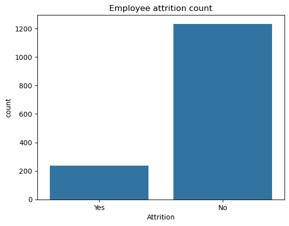

```python
sns.countplot(x='Attrition', data=df)
plt.title('Employee attrition count')
plt.show()
```

The count plot shows that most employees have not left the organization, while a smaller number of employees have left the company. This indicates a relatively low attrition rate and suggests that the organization has good employee retention. However, analyzing the reasons for employee attrition can help HR further improve retention policies.

```python
attrition_percentage=df['Attrition'].value_counts(normalize= True)*100
attrition_percentage
```

```
Attrition
No     83.877551
Yes    16.122449
Name: proportion, dtype: float64
```

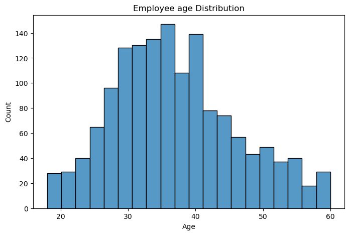

```python
plt.figure(figsize=(8,5))
sns.histplot(df['Age'], bins=20)
plt.title('Employee age Distribution')
plt.show()
```

The age distribution indicates that the majority of employees fall within the 25–40 years age range. This suggests that the organization primarily consists of young and mid-career professionals who are in their most productive working years. The presence of a strong workforce in this age group reflects a balanced employee base with potential for long-term growth and career development.

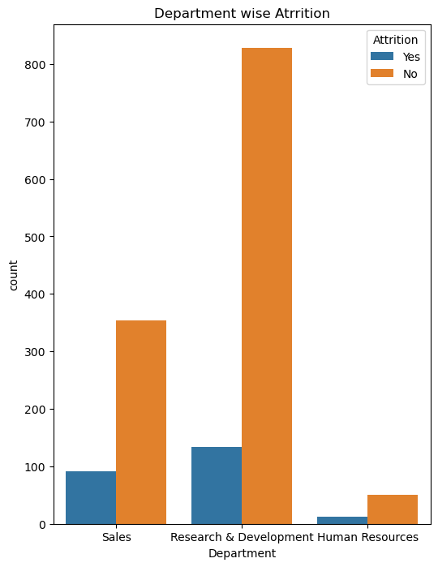

```python
plt.figure(figsize=(6,8))
sns.countplot(x='Department',hue='Attrition',data=df)
plt.title("Department wise Atrrition")
plt.show()
```

The department-wise attrition analysis shows that the Research & Development department has the highest number of employees who have not left the organization, indicating strong employee retention in this department. In contrast, the HR department has the lowest number of employees who left the company. These findings suggest that employee retention varies across departments and can help HR identify areas that may require targeted retention strategies.

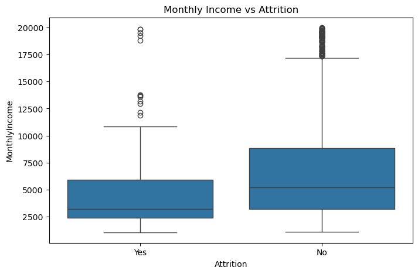

```python
plt.figure(figsize=(8,5))
sns.boxplot( x='Attrition',y='MonthlyIncome', data=df)
plt.title('Monthly Income vs Attrition')
plt.show()
```

The box plot compares the monthly income distribution of employees based on attrition status. The "No" category contains a larger number of employees than the "Yes" category, indicating that most employees have remained with the organization. While employees who left are fewer in number, the salary ranges of both groups overlap, suggesting that monthly income alone may not be the only factor influencing employee attrition.

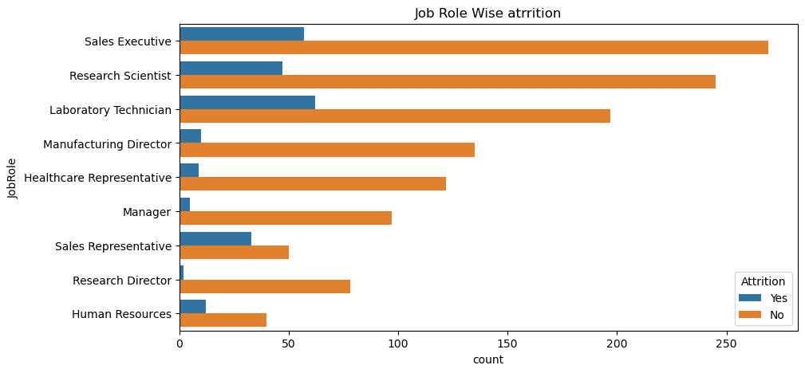

```python
plt.figure(figsize=(10,5))
sns.countplot(y='JobRole', hue='Attrition',data=df)
plt.title('Job Role Wise atrrition')
plt.show()
```

The job role-wise attrition analysis shows that Sales Executives have the highest number of employees who have not left the organization, while the Human Resources role has the lowest number of employees in the "No" category. Among employees who left the organization, Laboratory Technicians have the highest attrition count, whereas Research Directors have the lowest. These findings indicate that employee retention and attrition vary across job roles and can help HR identify roles that may require targeted retention strategies.

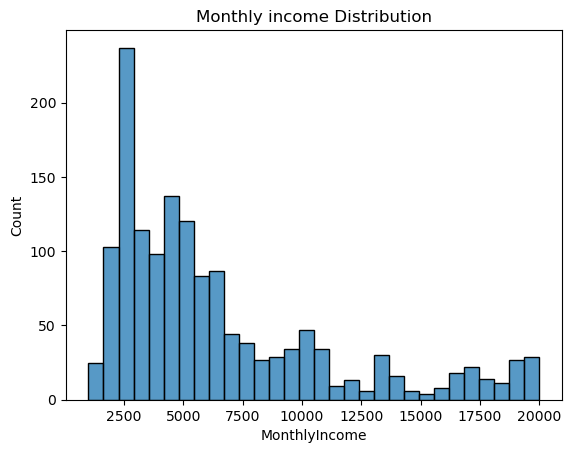

```python
sns.histplot(df['MonthlyIncome'],bins=30)
plt.title('Monthly income Distribution')
plt.show()
```

The monthly income distribution shows that most employees earn between 2,500 and 15,000. The distribution is concentrated in the lower and middle income ranges, while comparatively fewer employees receive higher salaries. This indicates that the organization has a larger workforce in entry-level and mid-level positions, with a smaller proportion of high-income employees.

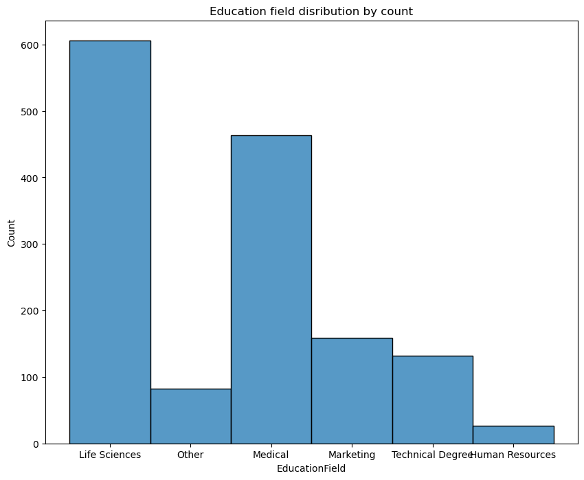

```python
plt.figure(figsize=(10,8))
sns.histplot(df['EducationField'], bins=20)
plt.title('Education field disribution by count')
plt.show()
```

The workforce is dominated by employees from Life Sciences and Medical backgrounds, while Human Resources has the smallest representation. This indicates that the company primarily recruits candidates with technical and science-related education, reflecting the nature of its business operations

```python
df['EducationField'].unique()
```

```
array(['Life Sciences', 'Other', 'Medical', 'Marketing',
       'Technical Degree', 'Human Resources'], dtype=object)
```

```python
df['YearsSinceLastPromotion'].unique()
```

```
array([ 0,  1,  3,  2,  7,  4,  8,  6,  5, 15,  9, 13, 12, 10, 11, 14])
```

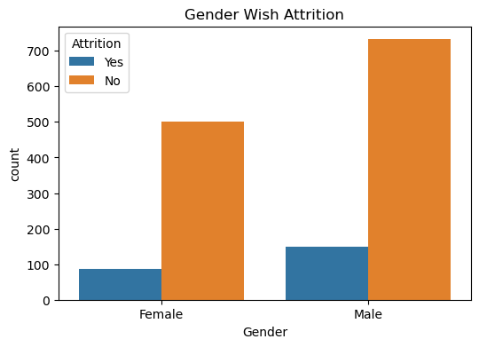

```python
plt.figure(figsize=(6,4))
sns.countplot(x='Gender',hue='Attrition', data=df)
plt.title('Gender Wish Attrition')
plt.show()
```

The company has a larger male workforce, and male employees also account for the highest number of attrition cases. However, employees of both genders are more likely to stay with the company than leave, indicating overall good employee retention

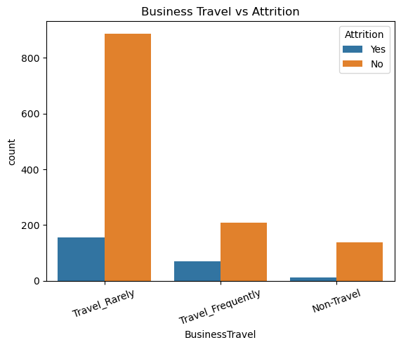

```python
sns.countplot(x='BusinessTravel',hue='Attrition',data=df)
plt.title('Business Travel vs Attrition')
plt.xticks(rotation=20)
plt.show()
```

Employees who travel rarely make up the largest workforce and therefore account for the highest number of attrition cases. However, employees who travel frequently also show a relatively higher attrition trend compared to non-travel employees, suggesting that business travel may influence employee retention

[figure not shown]

```python
sns.countplot(x='TrainingTimesLastYear',hue='Attrition',data =df)
plt.title(' TrainingTimesLastYears vs Attrition')
plt.show()
```

#### One-line recommendation

Company ko regular learning & development (L&D) programs continue rakhne chahiye aur 0–1 training wale employees par special focus karna chahiye taaki engagement aur retention improve ho sake.

```python
df
```

|  | Age | Attrition | BusinessTravel | DailyRate | Department | DistanceFromHome | Education | EducationField | EmployeeCount | EmployeeNumber | ... | StandardHours | StockOptionLevel | TotalWorkingYears | TrainingTimesLastYear | WorkLifeBalance | YearsAtCompany | YearsInCurrentRole | YearsSinceLastPromotion | YearsWithCurrManager | age_group |
| --- | --- | --- | --- | --- | --- | --- | --- | --- | --- | --- | --- | --- | --- | --- | --- | --- | --- | --- | --- | --- | --- |
| 0 | 41 | Yes | Travel_Rarely | 1102 | Sales | 1 | 2 | Life Sciences | 1 | 1 | ... | 80 | 0 | 8 | 0 | 1 | 6 | 4 | 0 | 5 | Middle Aged |
| 1 | 49 | No | Travel_Frequently | 279 | Research & Development | 8 | 1 | Life Sciences | 1 | 2 | ... | 80 | 1 | 10 | 3 | 3 | 10 | 7 | 1 | 7 | Senior |
| 2 | 37 | Yes | Travel_Rarely | 1373 | Research & Development | 2 | 2 | Other | 1 | 4 | ... | 80 | 0 | 7 | 3 | 3 | 0 | 0 | 0 | 0 | Middle Aged |
| 3 | 33 | No | Travel_Frequently | 1392 | Research & Development | 3 | 4 | Life Sciences | 1 | 5 | ... | 80 | 0 | 8 | 3 | 3 | 8 | 7 | 3 | 0 | Adult |
| 4 | 27 | No | Travel_Rarely | 591 | Research & Development | 2 | 1 | Medical | 1 | 7 | ... | 80 | 1 | 6 | 3 | 3 | 2 | 2 | 2 | 2 | Young Adult |
| ... | ... | ... | ... | ... | ... | ... | ... | ... | ... | ... | ... | ... | ... | ... | ... | ... | ... | ... | ... | ... | ... |
| 1465 | 36 | No | Travel_Frequently | 884 | Research & Development | 23 | 2 | Medical | 1 | 2061 | ... | 80 | 1 | 17 | 3 | 3 | 5 | 2 | 0 | 3 | Adult |
| 1466 | 39 | No | Travel_Rarely | 613 | Research & Development | 6 | 1 | Medical | 1 | 2062 | ... | 80 | 1 | 9 | 5 | 3 | 7 | 7 | 1 | 7 | Middle Aged |
| 1467 | 27 | No | Travel_Rarely | 155 | Research & Development | 4 | 3 | Life Sciences | 1 | 2064 | ... | 80 | 1 | 6 | 0 | 3 | 6 | 2 | 0 | 3 | Young Adult |
| 1468 | 49 | No | Travel_Frequently | 1023 | Sales | 2 | 3 | Medical | 1 | 2065 | ... | 80 | 0 | 17 | 3 | 2 | 9 | 6 | 0 | 8 | Senior |
| 1469 | 34 | No | Travel_Rarely | 628 | Research & Development | 8 | 3 | Medical | 1 | 2068 | ... | 80 | 0 | 6 | 3 | 4 | 4 | 3 | 1 | 2 | Adult |

1470 rows × 36 columns

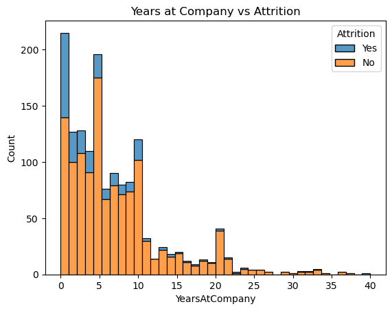

```python
sns.histplot(data=df, x='YearsAtCompany',hue="Attrition",multiple='stack')
plt.title("Years at Company vs Attrition")
plt.show()
```

"The highest employee attrition occurs during the first few years of employment. As employees spend more years in the company, attrition decreases significantly, indicating that long-term employees are more likely to stay with the organization.

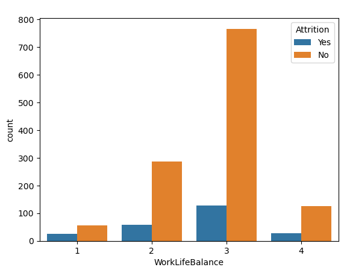

```python
sns.countplot( x='WorkLifeBalance',hue="Attrition",data=df)
plt.title(" ")
plt.show()
```

Most employees reported a Work-Life Balance rating of 3, and this group also showed the highest retention. Employees with better work-life balance generally appear more likely to stay with the company, highlighting the importance of maintaining a healthy work environment.

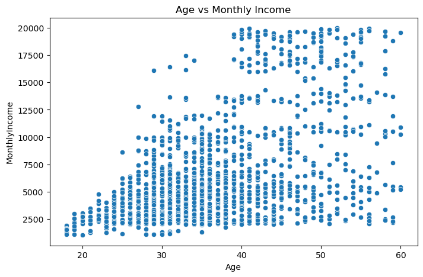

```python
plt.figure(figsize=(8,5))
sns.scatterplot(x='Age', y='MonthlyIncome', data=df)
plt.title("Age vs Monthly Income")
plt.show()
```

The scatter plot shows a positive relationship between age and monthly income. Older employees generally earn higher salaries, while younger employees mostly fall into lower income ranges. However, salary varies across all age groups, indicating that job role, experience, and position also influence employee income.

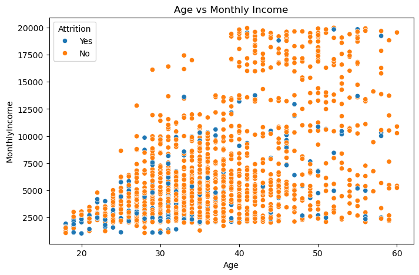

```python
plt.figure(figsize=(8,5))

sns.scatterplot(
    x='Age',
    y='MonthlyIncome',
    hue='Attrition',
    data=df
)

plt.title("Age vs Monthly Income")
plt.show()
```

```python
df["TotalExperience"] = df["YearsAtCompany"] + df["TotalWorkingYears"]
```

```python
df["IncomePerYear"] = df["MonthlyIncome"] * 12
```

```python
df
```

|  | Age | Attrition | BusinessTravel | DailyRate | Department | DistanceFromHome | Education | EducationField | EmployeeCount | EmployeeNumber | ... | TotalWorkingYears | TrainingTimesLastYear | WorkLifeBalance | YearsAtCompany | YearsInCurrentRole | YearsSinceLastPromotion | YearsWithCurrManager | age_group | TotalExperience | IncomePerYear |
| --- | --- | --- | --- | --- | --- | --- | --- | --- | --- | --- | --- | --- | --- | --- | --- | --- | --- | --- | --- | --- | --- |
| 0 | 41 | Yes | Travel_Rarely | 1102 | Sales | 1 | 2 | Life Sciences | 1 | 1 | ... | 8 | 0 | 1 | 6 | 4 | 0 | 5 | Middle Aged | 14 | 71916 |
| 1 | 49 | No | Travel_Frequently | 279 | Research & Development | 8 | 1 | Life Sciences | 1 | 2 | ... | 10 | 3 | 3 | 10 | 7 | 1 | 7 | Senior | 20 | 61560 |
| 2 | 37 | Yes | Travel_Rarely | 1373 | Research & Development | 2 | 2 | Other | 1 | 4 | ... | 7 | 3 | 3 | 0 | 0 | 0 | 0 | Middle Aged | 7 | 25080 |
| 3 | 33 | No | Travel_Frequently | 1392 | Research & Development | 3 | 4 | Life Sciences | 1 | 5 | ... | 8 | 3 | 3 | 8 | 7 | 3 | 0 | Adult | 16 | 34908 |
| 4 | 27 | No | Travel_Rarely | 591 | Research & Development | 2 | 1 | Medical | 1 | 7 | ... | 6 | 3 | 3 | 2 | 2 | 2 | 2 | Young Adult | 8 | 41616 |
| ... | ... | ... | ... | ... | ... | ... | ... | ... | ... | ... | ... | ... | ... | ... | ... | ... | ... | ... | ... | ... | ... |
| 1465 | 36 | No | Travel_Frequently | 884 | Research & Development | 23 | 2 | Medical | 1 | 2061 | ... | 17 | 3 | 3 | 5 | 2 | 0 | 3 | Adult | 22 | 30852 |
| 1466 | 39 | No | Travel_Rarely | 613 | Research & Development | 6 | 1 | Medical | 1 | 2062 | ... | 9 | 5 | 3 | 7 | 7 | 1 | 7 | Middle Aged | 16 | 119892 |
| 1467 | 27 | No | Travel_Rarely | 155 | Research & Development | 4 | 3 | Life Sciences | 1 | 2064 | ... | 6 | 0 | 3 | 6 | 2 | 0 | 3 | Young Adult | 12 | 73704 |
| 1468 | 49 | No | Travel_Frequently | 1023 | Sales | 2 | 3 | Medical | 1 | 2065 | ... | 17 | 3 | 2 | 9 | 6 | 0 | 8 | Senior | 26 | 64680 |
| 1469 | 34 | No | Travel_Rarely | 628 | Research & Development | 8 | 3 | Medical | 1 | 2068 | ... | 6 | 3 | 4 | 4 | 3 | 1 | 2 | Adult | 10 | 52848 |

1470 rows × 38 columns

```python
pd.pivot_table(
    df,
    values="MonthlyIncome",
    index="Department",
    aggfunc="mean"
)
```

| Department | MonthlyIncome |
| --- | --- |
| Human Resources | 6654.507937 |
| Research & Development | 6281.252862 |
| Sales | 6959.172646 |

```python
df.groupby("Department")["MonthlyIncome"].mean()
```

```
Department
Human Resources           6654.507937
Research & Development    6281.252862
Sales                     6959.172646
Name: MonthlyIncome, dtype: float64
```

```python
df.groupby(
    ["Department","Gender"]
)["MonthlyIncome"].mean()
```

```
Department              Gender
Human Resources         Female    7264.000000
                        Male      6371.023256
Research & Development  Female    6513.691293
                        Male      6129.888316
Sales                   Female    6972.126984
                        Male      6949.645914
Name: MonthlyIncome, dtype: float64
```

```python
df.groupby(
    ["Department","Gender"]
)["MonthlyIncome"].mean()
```

```
Department              Gender
Human Resources         Female    7264.000000
                        Male      6371.023256
Research & Development  Female    6513.691293
                        Male      6129.888316
Sales                   Female    6972.126984
                        Male      6949.645914
Name: MonthlyIncome, dtype: float64
```

```python
df.corr(numeric_only=True)
```

|  | Age | DailyRate | DistanceFromHome | Education | EmployeeCount | EmployeeNumber | EnvironmentSatisfaction | HourlyRate | JobInvolvement | JobLevel | ... | StockOptionLevel | TotalWorkingYears | TrainingTimesLastYear | WorkLifeBalance | YearsAtCompany | YearsInCurrentRole | YearsSinceLastPromotion | YearsWithCurrManager | TotalExperience | IncomePerYear |
| --- | --- | --- | --- | --- | --- | --- | --- | --- | --- | --- | --- | --- | --- | --- | --- | --- | --- | --- | --- | --- | --- |
| Age | 1.000000 | 0.010661 | -0.001686 | 0.208034 | NaN | -0.010145 | 0.010146 | 0.024287 | 0.029820 | 0.509604 | ... | 0.037510 | 0.680381 | -0.019621 | -0.021490 | 0.311309 | 0.212901 | 0.216513 | 0.202089 | 0.572964 | 0.497855 |
| DailyRate | 0.010661 | 1.000000 | -0.004985 | -0.016806 | NaN | -0.050990 | 0.018355 | 0.023381 | 0.046135 | 0.002966 | ... | 0.042143 | 0.014515 | 0.002453 | -0.037848 | -0.034055 | 0.009932 | -0.033229 | -0.026363 | -0.007615 | 0.007707 |
| DistanceFromHome | -0.001686 | -0.004985 | 1.000000 | 0.021042 | NaN | 0.032916 | -0.016075 | 0.031131 | 0.008783 | 0.005303 | ... | 0.044872 | 0.004628 | -0.036942 | -0.026556 | 0.009508 | 0.018845 | 0.010029 | 0.014406 | 0.007500 | -0.017014 |
| Education | 0.208034 | -0.016806 | 0.021042 | 1.000000 | NaN | 0.042070 | -0.027128 | 0.016775 | 0.042438 | 0.101589 | ... | 0.018422 | 0.148280 | -0.025100 | 0.009819 | 0.069114 | 0.060236 | 0.054254 | 0.069065 | 0.125488 | 0.094961 |
| EmployeeCount | NaN | NaN | NaN | NaN | NaN | NaN | NaN | NaN | NaN | NaN | ... | NaN | NaN | NaN | NaN | NaN | NaN | NaN | NaN | NaN | NaN |
| EmployeeNumber | -0.010145 | -0.050990 | 0.032916 | 0.042070 | NaN | 1.000000 | 0.017621 | 0.035179 | -0.006888 | -0.018519 | ... | 0.062227 | -0.014365 | 0.023603 | 0.010309 | -0.011240 | -0.008416 | -0.009019 | -0.009197 | -0.014373 | -0.014829 |
| EnvironmentSatisfaction | 0.010146 | 0.018355 | -0.016075 | -0.027128 | NaN | 0.017621 | 1.000000 | -0.049857 | -0.008278 | 0.001212 | ... | 0.003432 | -0.002693 | -0.019359 | 0.027627 | 0.001458 | 0.018007 | 0.016194 | -0.004999 | -0.000957 | -0.006259 |
| HourlyRate | 0.024287 | 0.023381 | 0.031131 | 0.016775 | NaN | 0.035179 | -0.049857 | 1.000000 | 0.042861 | -0.027853 | ... | 0.050263 | -0.002334 | -0.008548 | -0.004607 | -0.019582 | -0.024106 | -0.026716 | -0.020123 | -0.010990 | -0.015794 |
| JobInvolvement | 0.029820 | 0.046135 | 0.008783 | 0.042438 | NaN | -0.006888 | -0.008278 | 0.042861 | 1.000000 | -0.012630 | ... | 0.021523 | -0.005533 | -0.015338 | -0.014617 | -0.021355 | 0.008717 | -0.024184 | 0.025976 | -0.013835 | -0.015271 |
| JobLevel | 0.509604 | 0.002966 | 0.005303 | 0.101589 | NaN | -0.018519 | 0.001212 | -0.027853 | -0.012630 | 1.000000 | ... | 0.013984 | 0.782208 | -0.018191 | 0.037818 | 0.534739 | 0.389447 | 0.353885 | 0.375281 | 0.744917 | 0.950300 |
| JobSatisfaction | -0.004892 | 0.030571 | -0.003669 | -0.011296 | NaN | -0.046247 | -0.006784 | -0.071335 | -0.021476 | -0.001944 | ... | 0.010690 | -0.020185 | -0.005779 | -0.019459 | -0.003803 | -0.002305 | -0.018214 | -0.027656 | -0.014350 | -0.007157 |
| MonthlyIncome | 0.497855 | 0.007707 | -0.017014 | 0.094961 | NaN | -0.014829 | -0.006259 | -0.015794 | -0.015271 | 0.950300 | ... | 0.005408 | 0.772893 | -0.021736 | 0.030683 | 0.514285 | 0.363818 | 0.344978 | 0.344079 | 0.729180 | 1.000000 |
| MonthlyRate | 0.028051 | -0.032182 | 0.027473 | -0.026084 | NaN | 0.012648 | 0.037600 | -0.015297 | -0.016322 | 0.039563 | ... | -0.034323 | 0.026442 | 0.001467 | 0.007963 | -0.023655 | -0.012815 | 0.001567 | -0.036746 | 0.004839 | 0.034814 |
| NumCompaniesWorked | 0.299635 | 0.038153 | -0.029251 | 0.126317 | NaN | -0.001251 | 0.012594 | 0.022157 | 0.015012 | 0.142501 | ... | 0.030075 | 0.237639 | -0.066054 | -0.008366 | -0.118421 | -0.090754 | -0.036814 | -0.110319 | 0.089392 | 0.149515 |
| PercentSalaryHike | 0.003634 | 0.022704 | 0.040235 | -0.011111 | NaN | -0.012944 | -0.031701 | -0.009062 | -0.017205 | -0.034730 | ... | 0.007528 | -0.020608 | -0.005221 | -0.003280 | -0.035991 | -0.001520 | -0.022154 | -0.011985 | -0.030303 | -0.027269 |
| PerformanceRating | 0.001904 | 0.000473 | 0.027110 | -0.024539 | NaN | -0.020359 | -0.029548 | -0.002172 | -0.029071 | -0.021222 | ... | 0.003506 | 0.006744 | -0.015579 | 0.002572 | 0.003435 | 0.034986 | 0.017896 | 0.022827 | 0.005849 | -0.017120 |
| RelationshipSatisfaction | 0.053535 | 0.007846 | 0.006557 | -0.009118 | NaN | -0.069861 | 0.007665 | 0.001330 | 0.034297 | 0.021642 | ... | -0.045952 | 0.024054 | 0.002497 | 0.019604 | 0.019367 | -0.015123 | 0.033493 | -0.000867 | 0.024332 | 0.025873 |
| StandardHours | NaN | NaN | NaN | NaN | NaN | NaN | NaN | NaN | NaN | NaN | ... | NaN | NaN | NaN | NaN | NaN | NaN | NaN | NaN | NaN | NaN |
| StockOptionLevel | 0.037510 | 0.042143 | 0.044872 | 0.018422 | NaN | 0.062227 | 0.003432 | 0.050263 | 0.021523 | 0.013984 | ... | 1.000000 | 0.010136 | 0.011274 | 0.004129 | 0.015058 | 0.050818 | 0.014352 | 0.024698 | 0.013615 | 0.005408 |
| TotalWorkingYears | 0.680381 | 0.014515 | 0.004628 | 0.148280 | NaN | -0.014365 | -0.002693 | -0.002334 | -0.005533 | 0.782208 | ... | 0.010136 | 1.000000 | -0.035662 | 0.001008 | 0.628133 | 0.460365 | 0.404858 | 0.459188 | 0.925275 | 0.772893 |
| TrainingTimesLastYear | -0.019621 | 0.002453 | -0.036942 | -0.025100 | NaN | 0.023603 | -0.019359 | -0.008548 | -0.015338 | -0.018191 | ... | 0.011274 | -0.035662 | 1.000000 | 0.028072 | 0.003569 | -0.005738 | -0.002067 | -0.004096 | -0.020338 | -0.021736 |
| WorkLifeBalance | -0.021490 | -0.037848 | -0.026556 | 0.009819 | NaN | 0.010309 | 0.027627 | -0.004607 | -0.014617 | 0.037818 | ... | 0.004129 | 0.001008 | 0.028072 | 1.000000 | 0.012089 | 0.049856 | 0.008941 | 0.002759 | 0.006517 | 0.030683 |
| YearsAtCompany | 0.311309 | -0.034055 | 0.009508 | 0.069114 | NaN | -0.011240 | 0.001458 | -0.019582 | -0.021355 | 0.534739 | ... | 0.015058 | 0.628133 | 0.003569 | 0.012089 | 1.000000 | 0.758754 | 0.618409 | 0.769212 | 0.876329 | 0.514285 |
| YearsInCurrentRole | 0.212901 | 0.009932 | 0.018845 | 0.060236 | NaN | -0.008416 | 0.018007 | -0.024106 | 0.008717 | 0.389447 | ... | 0.050818 | 0.460365 | -0.005738 | 0.049856 | 0.758754 | 1.000000 | 0.548056 | 0.714365 | 0.654868 | 0.363818 |
| YearsSinceLastPromotion | 0.216513 | -0.033229 | 0.010029 | 0.054254 | NaN | -0.009019 | 0.016194 | -0.026716 | -0.024184 | 0.353885 | ... | 0.014352 | 0.404858 | -0.002067 | 0.008941 | 0.618409 | 0.548056 | 1.000000 | 0.510224 | 0.552092 | 0.344978 |
| YearsWithCurrManager | 0.202089 | -0.026363 | 0.014406 | 0.069065 | NaN | -0.009197 | -0.004999 | -0.020123 | 0.025976 | 0.375281 | ... | 0.024698 | 0.459188 | -0.004096 | 0.002759 | 0.769212 | 0.714365 | 0.510224 | 1.000000 | 0.659238 | 0.344079 |
| TotalExperience | 0.572964 | -0.007615 | 0.007500 | 0.125488 | NaN | -0.014373 | -0.000957 | -0.010990 | -0.013835 | 0.744917 | ... | 0.013615 | 0.925275 | -0.020338 | 0.006517 | 0.876329 | 0.654868 | 0.552092 | 0.659238 | 1.000000 | 0.729180 |
| IncomePerYear | 0.497855 | 0.007707 | -0.017014 | 0.094961 | NaN | -0.014829 | -0.006259 | -0.015794 | -0.015271 | 0.950300 | ... | 0.005408 | 0.772893 | -0.021736 | 0.030683 | 0.514285 | 0.363818 | 0.344978 | 0.344079 | 0.729180 | 1.000000 |

28 rows × 28 columns

```python
df.nlargest(10, "MonthlyIncome")
```

|  | Age | Attrition | BusinessTravel | DailyRate | Department | DistanceFromHome | Education | EducationField | EmployeeCount | EmployeeNumber | ... | TotalWorkingYears | TrainingTimesLastYear | WorkLifeBalance | YearsAtCompany | YearsInCurrentRole | YearsSinceLastPromotion | YearsWithCurrManager | age_group | TotalExperience | IncomePerYear |
| --- | --- | --- | --- | --- | --- | --- | --- | --- | --- | --- | --- | --- | --- | --- | --- | --- | --- | --- | --- | --- | --- |
| 190 | 52 | No | Travel_Rarely | 699 | Research & Development | 1 | 4 | Life Sciences | 1 | 259 | ... | 34 | 5 | 3 | 33 | 18 | 11 | 9 | Senior | 67 | 239988 |
| 746 | 41 | No | Non-Travel | 247 | Research & Development | 7 | 1 | Life Sciences | 1 | 1035 | ... | 21 | 3 | 3 | 21 | 16 | 5 | 10 | Middle Aged | 42 | 239676 |
| 851 | 56 | No | Travel_Rarely | 718 | Research & Development | 4 | 4 | Technical Degree | 1 | 1191 | ... | 28 | 2 | 3 | 5 | 2 | 4 | 2 | Senior | 33 | 239316 |
| 165 | 50 | No | Travel_Rarely | 1452 | Research & Development | 11 | 3 | Life Sciences | 1 | 226 | ... | 21 | 5 | 3 | 5 | 4 | 4 | 4 | Senior | 26 | 239112 |
| 568 | 55 | Yes | Travel_Rarely | 725 | Research & Development | 2 | 3 | Medical | 1 | 787 | ... | 24 | 2 | 3 | 5 | 2 | 1 | 4 | Senior | 29 | 238308 |
| 918 | 51 | No | Travel_Frequently | 237 | Sales | 9 | 3 | Life Sciences | 1 | 1282 | ... | 31 | 5 | 2 | 29 | 10 | 11 | 10 | Senior | 60 | 238164 |
| 749 | 52 | Yes | Travel_Rarely | 266 | Sales | 2 | 1 | Marketing | 1 | 1038 | ... | 33 | 3 | 3 | 32 | 14 | 6 | 9 | Senior | 65 | 238140 |
| 1242 | 40 | No | Travel_Rarely | 611 | Sales | 7 | 4 | Medical | 1 | 1740 | ... | 21 | 3 | 2 | 21 | 8 | 12 | 8 | Middle Aged | 42 | 237996 |
| 898 | 43 | No | Travel_Rarely | 920 | Research & Development | 3 | 3 | Life Sciences | 1 | 1255 | ... | 25 | 2 | 3 | 8 | 7 | 0 | 7 | Middle Aged | 33 | 236880 |
| 956 | 56 | No | Travel_Rarely | 206 | Human Resources | 8 | 4 | Life Sciences | 1 | 1338 | ... | 36 | 4 | 3 | 7 | 3 | 7 | 7 | Senior | 43 | 236604 |

10 rows × 38 columns

```python
df.nlargest(10, "MonthlyIncome")
```

|  | Age | Attrition | BusinessTravel | DailyRate | Department | DistanceFromHome | Education | EducationField | EmployeeCount | EmployeeNumber | ... | TotalWorkingYears | TrainingTimesLastYear | WorkLifeBalance | YearsAtCompany | YearsInCurrentRole | YearsSinceLastPromotion | YearsWithCurrManager | age_group | TotalExperience | IncomePerYear |
| --- | --- | --- | --- | --- | --- | --- | --- | --- | --- | --- | --- | --- | --- | --- | --- | --- | --- | --- | --- | --- | --- |
| 190 | 52 | No | Travel_Rarely | 699 | Research & Development | 1 | 4 | Life Sciences | 1 | 259 | ... | 34 | 5 | 3 | 33 | 18 | 11 | 9 | Senior | 67 | 239988 |
| 746 | 41 | No | Non-Travel | 247 | Research & Development | 7 | 1 | Life Sciences | 1 | 1035 | ... | 21 | 3 | 3 | 21 | 16 | 5 | 10 | Middle Aged | 42 | 239676 |
| 851 | 56 | No | Travel_Rarely | 718 | Research & Development | 4 | 4 | Technical Degree | 1 | 1191 | ... | 28 | 2 | 3 | 5 | 2 | 4 | 2 | Senior | 33 | 239316 |
| 165 | 50 | No | Travel_Rarely | 1452 | Research & Development | 11 | 3 | Life Sciences | 1 | 226 | ... | 21 | 5 | 3 | 5 | 4 | 4 | 4 | Senior | 26 | 239112 |
| 568 | 55 | Yes | Travel_Rarely | 725 | Research & Development | 2 | 3 | Medical | 1 | 787 | ... | 24 | 2 | 3 | 5 | 2 | 1 | 4 | Senior | 29 | 238308 |
| 918 | 51 | No | Travel_Frequently | 237 | Sales | 9 | 3 | Life Sciences | 1 | 1282 | ... | 31 | 5 | 2 | 29 | 10 | 11 | 10 | Senior | 60 | 238164 |
| 749 | 52 | Yes | Travel_Rarely | 266 | Sales | 2 | 1 | Marketing | 1 | 1038 | ... | 33 | 3 | 3 | 32 | 14 | 6 | 9 | Senior | 65 | 238140 |
| 1242 | 40 | No | Travel_Rarely | 611 | Sales | 7 | 4 | Medical | 1 | 1740 | ... | 21 | 3 | 2 | 21 | 8 | 12 | 8 | Middle Aged | 42 | 237996 |
| 898 | 43 | No | Travel_Rarely | 920 | Research & Development | 3 | 3 | Life Sciences | 1 | 1255 | ... | 25 | 2 | 3 | 8 | 7 | 0 | 7 | Middle Aged | 33 | 236880 |
| 956 | 56 | No | Travel_Rarely | 206 | Human Resources | 8 | 4 | Life Sciences | 1 | 1338 | ... | 36 | 4 | 3 | 7 | 3 | 7 | 7 | Senior | 43 | 236604 |

10 rows × 38 columns

```python
df[
    (df["Department"]=="Sales") &
    (df["Attrition"]=="Yes")
]
```

|  | Age | Attrition | BusinessTravel | DailyRate | Department | DistanceFromHome | Education | EducationField | EmployeeCount | EmployeeNumber | ... | TotalWorkingYears | TrainingTimesLastYear | WorkLifeBalance | YearsAtCompany | YearsInCurrentRole | YearsSinceLastPromotion | YearsWithCurrManager | age_group | TotalExperience | IncomePerYear |
| --- | --- | --- | --- | --- | --- | --- | --- | --- | --- | --- | --- | --- | --- | --- | --- | --- | --- | --- | --- | --- | --- |
| 0 | 41 | Yes | Travel_Rarely | 1102 | Sales | 1 | 2 | Life Sciences | 1 | 1 | ... | 8 | 0 | 1 | 6 | 4 | 0 | 5 | Middle Aged | 14 | 71916 |
| 21 | 36 | Yes | Travel_Rarely | 1218 | Sales | 9 | 4 | Life Sciences | 1 | 27 | ... | 10 | 4 | 3 | 5 | 3 | 0 | 3 | Adult | 15 | 40884 |
| 33 | 39 | Yes | Travel_Rarely | 895 | Sales | 5 | 3 | Technical Degree | 1 | 42 | ... | 19 | 6 | 4 | 1 | 0 | 0 | 0 | Middle Aged | 20 | 25032 |
| 36 | 50 | Yes | Travel_Rarely | 869 | Sales | 3 | 2 | Marketing | 1 | 47 | ... | 3 | 2 | 3 | 3 | 2 | 0 | 2 | Senior | 6 | 32196 |
| 89 | 46 | Yes | Travel_Rarely | 669 | Sales | 9 | 2 | Medical | 1 | 118 | ... | 9 | 3 | 3 | 9 | 8 | 4 | 7 | Senior | 18 | 115428 |
| ... | ... | ... | ... | ... | ... | ... | ... | ... | ... | ... | ... | ... | ... | ... | ... | ... | ... | ... | ... | ... | ... |
| 1395 | 31 | Yes | Travel_Frequently | 754 | Sales | 26 | 4 | Marketing | 1 | 1967 | ... | 10 | 4 | 3 | 10 | 7 | 0 | 8 | Adult | 20 | 67404 |
| 1396 | 53 | Yes | Travel_Rarely | 1168 | Sales | 24 | 4 | Life Sciences | 1 | 1968 | ... | 15 | 2 | 2 | 2 | 2 | 2 | 2 | Senior | 17 | 125376 |
| 1438 | 23 | Yes | Travel_Frequently | 638 | Sales | 9 | 3 | Marketing | 1 | 2023 | ... | 1 | 3 | 2 | 1 | 0 | 1 | 0 | Young Adult | 2 | 21480 |
| 1452 | 50 | Yes | Travel_Frequently | 878 | Sales | 1 | 4 | Life Sciences | 1 | 2044 | ... | 12 | 3 | 3 | 6 | 3 | 0 | 1 | Senior | 18 | 80736 |
| 1461 | 50 | Yes | Travel_Rarely | 410 | Sales | 28 | 3 | Marketing | 1 | 2055 | ... | 20 | 3 | 3 | 3 | 2 | 2 | 0 | Senior | 23 | 130248 |

92 rows × 38 columns

```python
Q1 = df["MonthlyIncome"].quantile(0.25)

Q3 = df["MonthlyIncome"].quantile(0.75)

IQR = Q3 - Q1

lower = Q1 - 1.5 * IQR

upper = Q3 + 1.5 * IQR

outliers = df[
    (df["MonthlyIncome"] < lower) |
    (df["MonthlyIncome"] > upper)
]

outliers
```

|  | Age | Attrition | BusinessTravel | DailyRate | Department | DistanceFromHome | Education | EducationField | EmployeeCount | EmployeeNumber | ... | TotalWorkingYears | TrainingTimesLastYear | WorkLifeBalance | YearsAtCompany | YearsInCurrentRole | YearsSinceLastPromotion | YearsWithCurrManager | age_group | TotalExperience | IncomePerYear |
| --- | --- | --- | --- | --- | --- | --- | --- | --- | --- | --- | --- | --- | --- | --- | --- | --- | --- | --- | --- | --- | --- |
| 25 | 53 | No | Travel_Rarely | 1282 | Research & Development | 5 | 3 | Other | 1 | 32 | ... | 26 | 3 | 2 | 14 | 13 | 4 | 8 | Senior | 40 | 229128 |
| 29 | 46 | No | Travel_Rarely | 705 | Sales | 2 | 4 | Marketing | 1 | 38 | ... | 22 | 2 | 2 | 2 | 2 | 2 | 1 | Senior | 24 | 227364 |
| 45 | 41 | Yes | Travel_Rarely | 1360 | Research & Development | 12 | 3 | Technical Degree | 1 | 58 | ... | 23 | 0 | 3 | 22 | 15 | 15 | 8 | Middle Aged | 45 | 234540 |
| 62 | 50 | No | Travel_Rarely | 989 | Research & Development | 7 | 2 | Medical | 1 | 80 | ... | 29 | 2 | 2 | 27 | 3 | 13 | 8 | Senior | 56 | 224880 |
| 105 | 59 | No | Non-Travel | 1420 | Human Resources | 2 | 4 | Human Resources | 1 | 140 | ... | 30 | 3 | 3 | 3 | 2 | 2 | 2 | Senior | 33 | 226128 |
| ... | ... | ... | ... | ... | ... | ... | ... | ... | ... | ... | ... | ... | ... | ... | ... | ... | ... | ... | ... | ... | ... |
| 1374 | 58 | No | Travel_Rarely | 605 | Sales | 21 | 3 | Life Sciences | 1 | 1938 | ... | 29 | 2 | 2 | 1 | 0 | 0 | 0 | Senior | 30 | 214500 |
| 1377 | 49 | No | Travel_Frequently | 1064 | Research & Development | 2 | 1 | Life Sciences | 1 | 1941 | ... | 28 | 3 | 3 | 5 | 4 | 4 | 3 | Senior | 33 | 229932 |
| 1401 | 55 | No | Travel_Rarely | 189 | Human Resources | 26 | 4 | Human Resources | 1 | 1973 | ... | 35 | 0 | 3 | 10 | 9 | 1 | 4 | Senior | 45 | 235632 |
| 1437 | 39 | No | Non-Travel | 105 | Research & Development | 9 | 3 | Life Sciences | 1 | 2022 | ... | 21 | 3 | 2 | 6 | 0 | 1 | 3 | Middle Aged | 27 | 233172 |
| 1443 | 42 | No | Travel_Rarely | 300 | Research & Development | 2 | 3 | Life Sciences | 1 | 2031 | ... | 24 | 2 | 2 | 22 | 6 | 4 | 14 | Middle Aged | 46 | 226560 |

114 rows × 38 columns

```python
total_employee = df.shape[0]

print("Total Employees :", total_employee)
```

```
Total Employees : 1470
```

```python
attrition = df[df["Attrition"] == "Yes"].shape[0]

print("Employees Left :", attrition)
```

```
Employees Left : 237
```

```python
attrition_rate = (attrition / total_employee) * 100

print("Attrition Rate :", round(attrition_rate,2), "%")
```

```
Attrition Rate : 16.12 %
```

```python
average_salary = df["MonthlyIncome"].mean()

print("Average Salary :", round(average_salary,2))
```

```
Average Salary : 6502.93
```

```python
highest_salary = df["MonthlyIncome"].max()

print("Highest Salary :", highest_salary)
```

```
Highest Salary : 19999
```

```python
df["Department"].value_counts()
```

```
Department
Research & Development    961
Sales                     446
Human Resources            63
Name: count, dtype: int64
```

```python
df.groupby("Department")["MonthlyIncome"].mean()
```

```
Department
Human Resources           6654.507937
Research & Development    6281.252862
Sales                     6959.172646
Name: MonthlyIncome, dtype: float64
```

```python
df["Gender"].value_counts()
```

```
Gender
Male      882
Female    588
Name: count, dtype: int64
```

```python
pd.crosstab(df["OverTime"], df["Attrition"])
```

| Attrition OverTime | No | Yes |
| --- | --- | --- |
| No | 944 | 110 |
| Yes | 289 | 127 |

```python
df.groupby("Education")["MonthlyIncome"].mean()
```

```
Education
1    5640.570588
2    6226.645390
3    6517.263986
4    6832.402010
5    8277.645833
Name: MonthlyIncome, dtype: float64
```

```python
bins = [18,25,35,45,55,65]

labels = ["18-25","26-35","36-45","46-55","56-65"]

df["AgeGroup"] = pd.cut(df["Age"], bins=bins, labels=labels)

df["AgeGroup"].value_counts()
```

```
AgeGroup
26-35    606
36-45    468
46-55    226
18-25    115
56-65     47
Name: count, dtype: int64
```

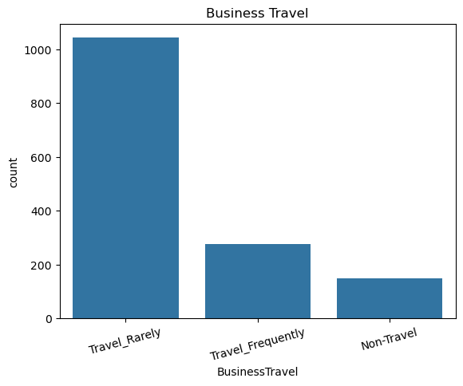

```python
sns.countplot(x='BusinessTravel', data=df)
plt.xticks(rotation=15)
plt.title("Business Travel")
plt.show()
```

The majority of employees travel rarely for business, while only a small proportion travel frequently or do not travel at all. This suggests that most job roles require occasional business travel rather than continuous travel

## Overall Business Recommendations (IBM HR Analytics Project)

Based on the complete analysis of Education Field, Gender, Business Travel, Training, Years at Company, Work-Life Balance, and Monthly Income, the company should consider the following actions:

### 1. Reduce Early Employee Attrition

Focus on employees in their first 1–5 years. Improve onboarding, mentoring, and career development programs. Conduct regular one-on-one meetings with new employees.

### 2. Strengthen Learning & Development

Provide 2–4 quality training sessions every year. Offer role-specific technical and soft-skill training. Create clear learning and career growth paths.

### 3. Improve Work-Life Balance

Introduce flexible work schedules where possible. Monitor employee workload to avoid burnout. Expand wellness and mental health initiatives.

### 4. Optimize Business Travel

Reduce unnecessary travel by using virtual meetings. Provide better travel allowances and recovery time for frequent travelers. Regularly review travel policies based on employee feedback.

### 5. Improve Employee Retention

Conduct stay interviews with high-performing employees. Recognize employee achievements through rewards and appreciation. Build transparent promotion and career progression policies.

### 6. Salary & Career Growth

Review salary structure regularly to ensure market competitiveness. Provide performance-based increments and promotions. Maintain transparent compensation policies.

### 7. Data-Driven HR Decisions

Track monthly attrition, promotions, training completion, and employee satisfaction using HR dashboards. Identify high-risk employees using predictive analytics and intervene early.

# Overall Conclusion

#### The analysis indicates that the company has strong overall employee retention, as the number of employees staying with the organization is significantly higher than those leaving.

#### However, the analysis also highlights several areas that require attention:

#### Attrition is highest among employees in their early years with the company.

#### Employees with poor work-life balance and frequent business travel may require additional support.

#### Continuous training and career development appear to contribute positively to employee retention.

#### Monthly income generally increases with age and experience, reflecting career progression within the organization.

#### The workforce is primarily composed of employees from Life Sciences and Medical backgrounds, indicating the company's focus on technical and scientific talent.

#### Overall, the company should focus on employee engagement, learning & development, work-life balance, competitive compensation, and data-driven HR strategies. Implementing these initiatives can help reduce attrition, improve employee satisfaction, and enhance long-term organizational performance.